# Galton Heights Regression

Author

Group 16 - Euna Ao // Alice Le // Isaac So // Mandy Yu

Published

March 21, 2026

# Predicting Child Height from Parental Height: A Linear Regression Analysis of the Galton Height Dataset

## Introduction

Human height is influenced by a combination of genetic and environmental factors, but parental height is often considered a strong predictor of a child’s height. Early statistical work by Francis Galton demonstrated that the average height of both parents, known as midparent height, provides a strong indicator of a child’s expected height (Galton 1886). Galton also observed that children’s heights tend to regress toward the population average rather than exactly matching their parents, a phenomenon later known as regression toward the mean. The Galton Height dataset, collected in the late 19th century, contains measurements of parents’ heights and the heights of their children. The dataset includes a variable called midparent height, which is calculated as $(\text{father} + 1.08 \times \text{mother})/2$, adjusting for the typical height difference between men and women. This allows us to study how parental height relates to the height of their child. In this analysis, we aim to answer the question: **Can a child’s height be predicted based on their parents’ heights?** To address this question, we build a multiple linear regression model to examine the relationship between midparent height and child height while also accounting for the child’s gender. By fitting the model on a training dataset and evaluating its performance on a testing dataset, we assess how well parental height and gender together predict child height. This analysis provides a better understanding of how parental height contributes to variation in child height.

## Methods

To investigate the relationship between parental height and child height, we conducted a mutiple linear regression analysis using the Galton Height dataset. The dataset was randomly split into training (80%) and testing (20%) sets. The training dataset was used to fit the regression model, while the testing dataset was used to evaluate the model’s predictive performance.

A multiple linear regression model was fitted with child’s height as the response variable, and the midparent height and child’s gender as predictor variables.

## Dataset and Exploratory Data Analysis

From the summary statistics, the average child height is about 66.75 inches, with heights ranging from 56 inches to 79 inches. The dataset also contains slightly more male children than female children. After checking for missing values, we found that there are no missing observations (Table 1), meaning the dataset is complete and can be used directly for further analysis.

Table 1: Number of missing values for each variable in the Galton Height dataset.

| variable | missing_values |
| --- | --- |
| rownames | 0 |
| family | 0 |
| father_height | 0 |
| mother_height | 0 |
| midparent_height | 0 |
| children | 0 |
| childNum | 0 |
| gender | 0 |
| child_height | 0 |

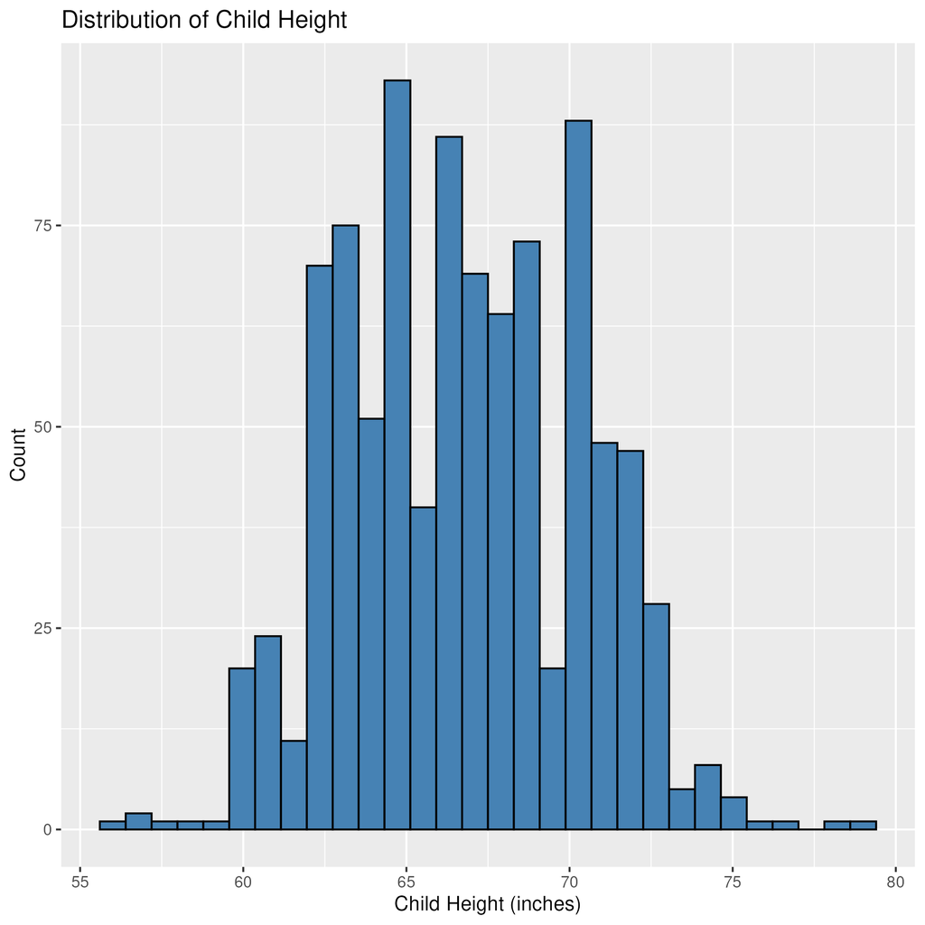

Figure 1: Distribution of child height in the Galton Height dataset.

Figure 1 shows that child heights are roughly normally distributed. Most children in the dataset have heights between about 60 and 72 inches, with the center of the distribution around 66–67 inches. There are fewer observations at the very short and very tall ends of the distribution. This pattern suggests that child height follows a fairly typical bell-shaped distribution, which is common for biological traits like height.

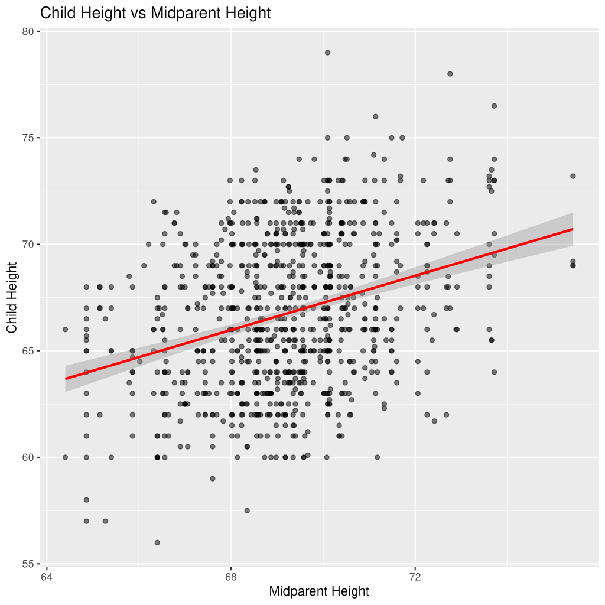

Figure 2: Relationship between midparent height and child height. Each point represents one child in the dataset.”

This scatterplot (Figure 2) explores the relationship between a child’s height and the average height of their parents (midparent height). There is a clear positive trend, meaning that children with taller parents tend to be taller themselves. Although there is still variability in the data, the upward trend suggests that parental height is an important factor influencing a child’s height. This relationship indicates that midparent height may be a useful predictor when building a model to estimate child height.

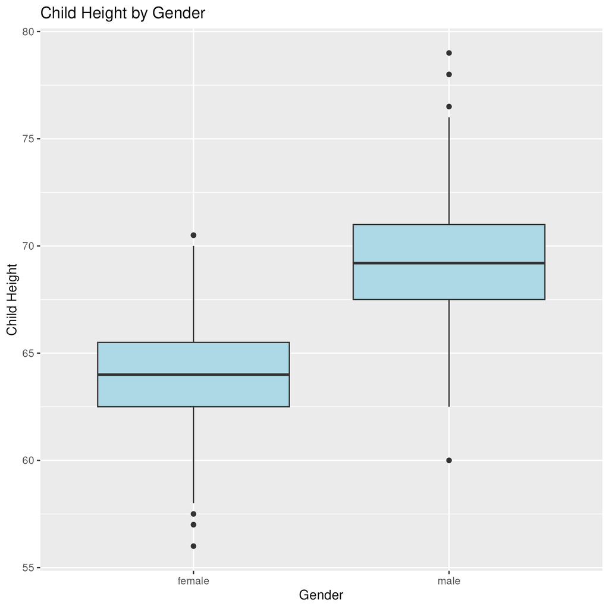

Figure 3: Distribution of child height by gender in the Galton Height dataset.”

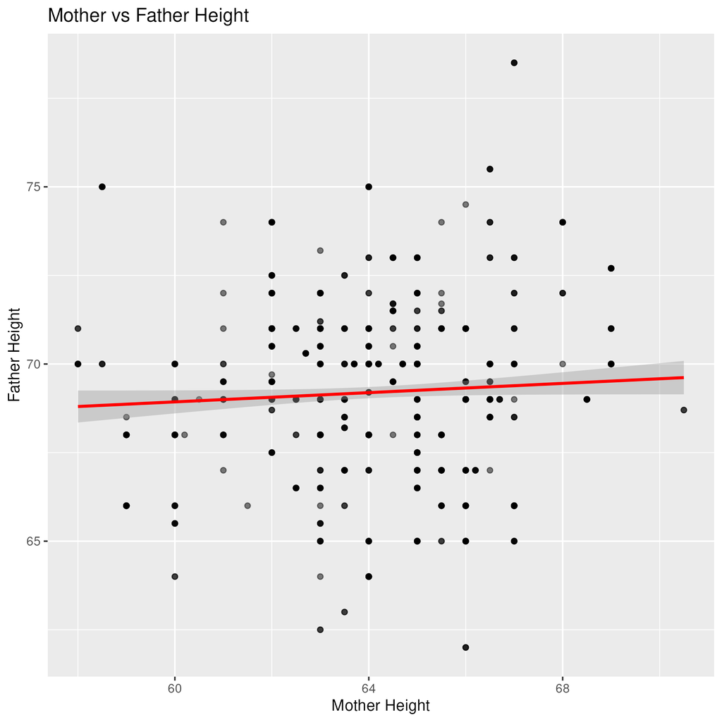

Figure 4: Relationship between mother’s height and father’s height in the dataset.”

This scatterplot (Figure 4) shows the relationship between the heights of mothers and fathers in the dataset. There appears to be a slight upward trend, suggesting that taller fathers tend to have somewhat taller partners as well. However, the points are still fairly spread out, so the relationship is not very strong. Because the two variables are somewhat related, using both mother and father height as predictors in a regression model could introduce a small amount of multicollinearity, meaning the variables may contain overlapping information about parental height.

## Results

Table 2: Estimated coefficients from the multiple linear regression model predicting child height.

| term | estimate | std.error | statistic | p.value |
| --- | --- | --- | --- | --- |
| (Intercept) | 16.1354019 | 3.033358 | 5.31932 | 1e-07 |
| midparent_height | 0.6931408 | 0.043781 | 15.83200 | 0e+00 |
| gendermale | 5.2104964 | 0.156879 | 33.21348 | 0e+00 |

The fitted regression model produced the following equation:

$\text{Child Height} = 16.135 + 0.693 (\text{Midparent Height}) + 5.21 (\text{Male})$

Table 3: Test-set performance metrics for the multiple linear regression model.

| .estimator | rmse | rsq | mae |
| --- | --- | --- | --- |
| standard | 2.282183 | 0.6159446 | 1.762045 |

As displayed in Table 3, the model achieved a root mean squared error (RMSE) of 2.28 inches and a mean absolute error (MAE) of 1.76 inches, indicating that predictions were typically within approximately 2 inches of the true child height. The model explained 61.6% of the variation in child height (R² = 0.616).

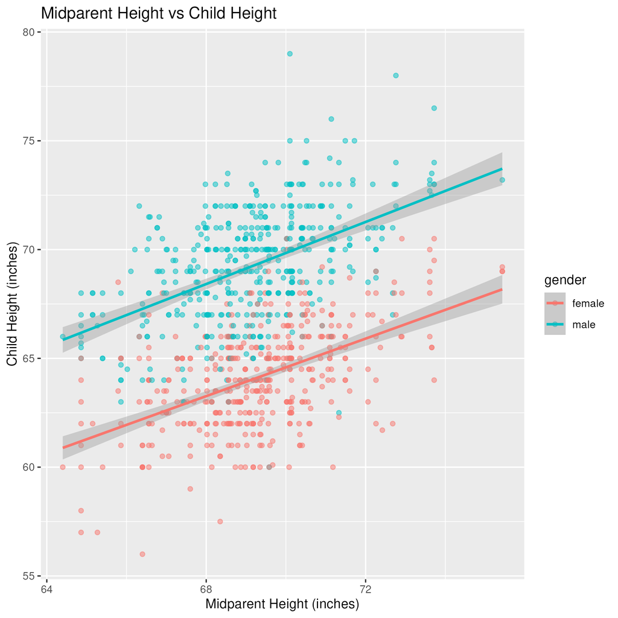

Figure 5 shows the relationship between midparent height and child height, with separate regression lines for male and female children. The positive slope for both lines indicates that taller parents tend to have taller children. The colour separation between male and female points in the scatterplot reflects the gender difference, with male children generally having greater predicted heights than female children at the same midparent height.

## Discussion

The results are not surprising and are rather expected. Height is well recognized to have strong genetic components, and is largely hereditary and passed from parents to offspring. For example, the Tanner method (Tanner, Goldstein, and Whitehouse 1970) estimates offspring height by averaging the adjusted height of the parents.

Our results align with existing research that examines the relationship between parental height and offspring height, such as Galton’s original analysis in 1886. These findings have clear applications in healthcare and early disease detection. Being able to predict offspring height from parent height will allow healthcare providers to estimate expected heights for offspring, which can act as a baseline to gauge healthy growth and development.

##### Limitations

However, further research has recognized that height is also influenced by environmental factors, such as socio-economic status (Bozzoli, Deaton, and Quintana-Domeque 2009) and the education level received by the parents (Jelenkovic et al. 2020). As our dataset only contains data regarding the parents’ height, offspring height, and offspring gender, our model fails to capture other explanatory variables that are influential in determining offspring height.

Additionally, our model used multivariate regression as our primary supervised learning technique, which assumes linearity in the data. While it produced reasonable results, we have not tried other non-linear models, which may produce better results and capture non-linear patterns in our data.

The data itself may also contain bias and is non-representative of the global population. As the data was collected before 1886, it likely only contained data about English families and would not be an accurate representation of other demographics nor reflect modern improvements in dietary patterns, lifestyle, and societal norms.

Lastly, our dataset is relatively small with only 934 children. A larger dataset would allow for more sophisticated machine learning techniques such as larger train/test splits, cross-validation, and hyperparameter tuning.

##### Future Questions

Future areas to explore include re-examining the role of parental height and gender in predicting offspring height but with data collected recently, such as post 2000s across a global population. The role of birth order on height (i.e., first-born, second-born, etc.) and its interaction with gender and parents’ height variables could also give insights into how family dynamics influence offspring height.

## References

Bozzoli, Carlos, Angus Deaton, and Climent Quintana-Domeque. 2009. “Adult Height and Childhood Disease.” *Demography* 46 (4): 647–69.

Galton, Francis. 1886. “Regression Towards Mediocrity in Hereditary Stature.” *The Journal of the Anthropological Institute of Great Britain and Ireland* 15: 246–63.

Jelenkovic, Aline, Reijo Sund, Yoshie Yokoyama, Antti Latvala, Masumi Sugawara, Mami Tanaka, Satoko Matsumoto, et al. 2020. “Genetic and Environmental Influences on Human Height from Infancy Through Adulthood at Different Levels of Parental Education.” *Scientific Reports* 10 (1): 7974.

Tanner, JM, H Goldstein, and RH Whitehouse. 1970. “Standards for Children’s Height at Age 2 to 9 Years Allowing for Height of Parents.” *Archives of Disease in Childhood* 45 (244): 819.